# Severe Weather Effects on Public Health and the Economy

Juan Jose

Tuesday, February 17, 2015

# Data Processing

#### This section explains how the data is loaded into R and any transformations that were done to the raw data in order to perform the analysis.

*Note we assume you have downloaded the file and unzipped it to ‘repdata-data-StormData.csv’ and that you are executing this R script in the directory where the file is located.*

First the data is loaded and any additional libraries.

```r
library(dplyr)
```

```r
library(ggplot2)
```

```r
storm.data <- read.csv('repdata-data-StormData.csv', strip.white=TRUE)
names(storm.data)
```

```
##  [1] "STATE__"    "BGN_DATE"   "BGN_TIME"   "TIME_ZONE"  "COUNTY"
##  [6] "COUNTYNAME" "STATE"      "EVTYPE"     "BGN_RANGE"  "BGN_AZI"
## [11] "BGN_LOCATI" "END_DATE"   "END_TIME"   "COUNTY_END" "COUNTYENDN"
## [16] "END_RANGE"  "END_AZI"    "END_LOCATI" "LENGTH"     "WIDTH"
## [21] "F"          "MAG"        "FATALITIES" "INJURIES"   "PROPDMG"
## [26] "PROPDMGEXP" "CROPDMG"    "CROPDMGEXP" "WFO"        "STATEOFFIC"
## [31] "ZONENAMES"  "LATITUDE"   "LONGITUDE"  "LATITUDE_E" "LONGITUDE_"
## [36] "REMARKS"    "REFNUM"
```

Not all of the entries in the EVTYPE column are of the same case, so they need to be all capitalized in order to increase accuracy.

```r
storm.data$EVTYPE <- toupper(storm.data$EVTYPE)
```

The data set provides variables that can be used to answer the question of how weather events affect public health. * FATALITIES * INJURIES We can subset the data to only get the instances where there were injuries and fatalities as a result of extreme weather events.

```r
#make a new data frame for this analysis
health <- data.frame(storm.data$EVTYPE, storm.data$INJURIES, storm.data$FATALITIES)

#subset the new data frame to get injuries and fatalities
names(health) <- c("event", "injuries", "fatalities")
health <- subset(health, injuries > 0 | fatalities > 0)

health <- health %>% group_by(event) %>% summarise_each(funs(sum))
injuries <- data.frame(health$event, health$injuries)
names(injuries) <- c("event", "count")
fatalities <- data.frame(health$event, health$fatalities)
names(fatalities) <- c("event", "count")

fatalities <- head(fatalities[order(fatalities$count, decreasing=TRUE), ], 10)
injuries   <- head(injuries[order(injuries$count, decreasing=TRUE), ], 10)
```

The data set provides four variables that can be used to answer the question of how weather events affect the economy. * PROPDMG * PROPDMGEXP * CROPDMG * CROPDMGEXP First, we create a new data frame for the economic analysis using these variables.

```r
econ <- data.frame(storm.data$EVTYPE, storm.data$PROPDMG, storm.data$PROPDMGEXP, storm.data$CROPDMG, storm.data$CROPDMGEXP)
#change the names to facilitate usage
names(econ) <- c("event", "prop.dmg", "prop.exp", "crop.dmg", "crop.exp")
```

The two columns with the exp in the name are what we need to multiply by in order to get the real damange.

```r
unique(econ$crop.exp)
```

```
## [1]   M K m B ? 0 k 2
## Levels:  ? 0 2 B k K m M
```

```r
unique(econ$prop.exp)
```

```
##  [1] K M   B m + 0 5 6 ? 4 2 3 h 7 H - 1 8
## Levels:  - ? + 0 1 2 3 4 5 6 7 8 B h H K m M
```

We need to do some transformations to these data in order to use them.

```r
#convert all entries to the same case
econ$crop.exp <- toupper(econ$crop.exp)
econ$prop.exp <- toupper(econ$prop.exp)

#convert the letters into numbers
#make a function to use in sapply to conver every entry into a number
convert.fun <- function(entry) {

        if      (entry == 'H')
                ret = 100
        else if (entry == 'K')
                ret = 1000
        else if (entry == 'M')
                ret = 1000000
        else if (entry == 'B')
                ret = 1000000000
        else
                ret = 1
        return (ret)
}

econ$prop.exp <- sapply(econ$prop.exp, FUN=convert.fun)
econ$crop.exp <- sapply(econ$crop.exp, FUN=convert.fun)

#now use the exponents to get the property damage
econ$prop.dmg <- econ$prop.dmg * econ$prop.exp
econ$crop.dmg <- econ$crop.dmg * econ$crop.exp

#get the total damage for properties and crops
tot.prop <- data.frame(econ$event, econ$prop.dmg)
names(tot.prop) = c("event", "amount")
tot.crop <- data.frame(econ$event, econ$crop.dmg)
names(tot.crop) = c("event", "amount")

#combine property and crop damage
tot.dmg = rbind(tot.prop, tot.crop)

#aggregate it by events and then get the top 10 records
tot.dmg = aggregate(tot.dmg$amount, by=list(tot.dmg$event), FUN=sum)
names(tot.dmg) = c("event", "amount")
tot.dmg = head(tot.dmg[order(tot.dmg$amount, decreasing=TRUE), ] , 10)
```

Now we have three data frames with the data needed to answer the questions.

# Results

## Effects of Weather on Public Health

INJURIES

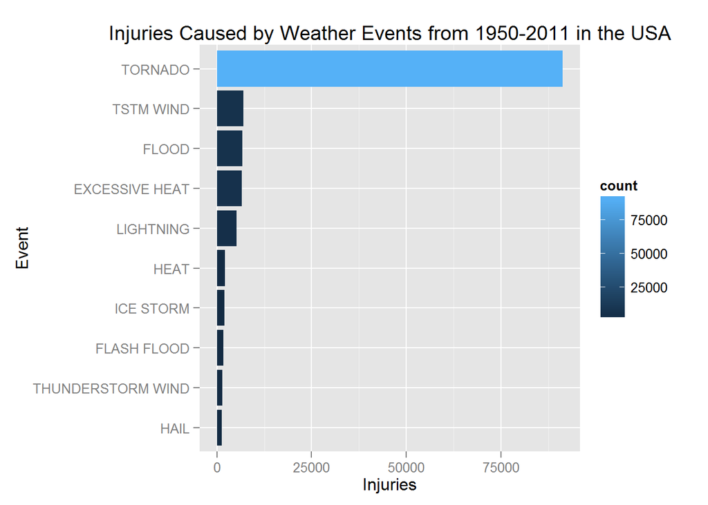

```r
qplot(x=reorder(event, count), y=count, data=injuries, geom=c("bar"), stat="identity", xlab="Event", ylab="Injuries", main="Injuries Caused by Weather Events from 1950-2011 in the USA", fill=count) + coord_flip()
```

FATALITIES

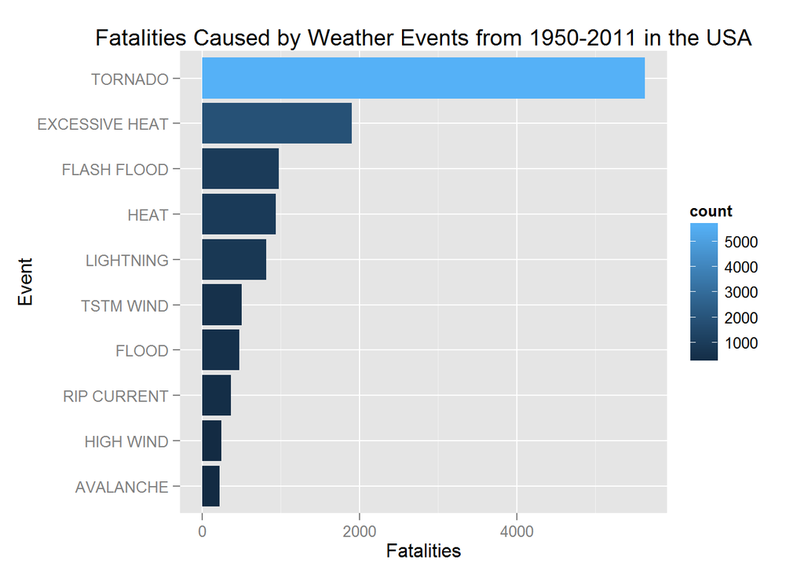

```r
qplot(x=reorder(event, count), y=count, data=fatalities, geom=c("bar"), stat="identity", xlab="Event", ylab="Fatalities", main="Fatalities Caused by Weather Events from 1950-2011 in the USA", fill=count) + coord_flip()
```

## Effects of weather on the Economy

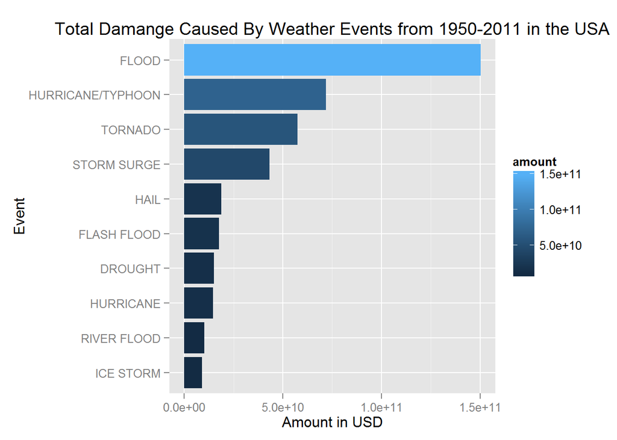

```r
qplot(x=reorder(event, amount), y=amount, data=tot.dmg, geom=c("bar"), stat="identity", xlab="Event", ylab="Amount in USD", main="Total Damange Caused By Weather Events from 1950-2011 in the USA", fill=amount) + coord_flip()
```